# Airbnb Listing Price Prediction & Neighbourhood Segmentation

An Explainable Machine Learning and Unsupervised Segmentation Case Study in R

Department of Artificial Intelligence & Data Science, CBIT Hyderabad

2026-10-25

# 1 Introduction

In short-term accommodation markets such as Airbnb, dynamic and accurate listing price valuation is critical for both property hosts and guests. For hosts, setting a competitive nightly rate dictates booking velocity, listing visibility, and overall revenue; underpricing forfeits margin, while overpricing leads to vacant calendar days and algorithmic deprioritization. For traveling consumers, price transparency ensures fair valuation relative to space, privacy, and geographic accessibility.

This project implements an end-to-end Introduction to Data Science (IDS) case study in **R** using the official 2019 New York City Inside Airbnb snapshot (`AB_NYC_2019.csv`). The study bridges two core paradigms of statistical data science: 1. **Supervised Regression & Explainable Machine Learning**: Establishing an interpretable baseline using Multiple Linear Regression, comparing it against a non-parametric Random Forest regressor on identical held-out test data, and explaining individual test predictions locally using **LIME** (Local Interpretable Model-agnostic Explanations). 2. **Unsupervised Market Segmentation**: Applying **K-means clustering** on aggregated neighbourhood-level metrics (pricing, unit supply density, and room capacity mix) to identify empirical market tiers across New York City without arbitrary prior assumptions.

# 2 Problem Statement and Objectives

### 2.0.1 Problem Statement

Can an Airbnb listing’s nightly price in New York City be reliably predicted from its structural room characteristics, host commercial intensity, and geospatial coordinates? Furthermore, can unsupervised clustering over aggregated neighbourhood statistics uncover distinct geographic market segments that reflect structural socio-economic variations across the metropolitan area?

### 2.0.2 Primary Objectives

1. **Dataset Inspection & Rigorous Preprocessing**: Empirically inspect data types, missingness, and invalid values in `AB_NYC_2019.csv`. Apply the standard Interquartile Range (IQR) rule to mitigate extreme price distortions while preserving authentic variance, preventing data leakage across training and testing partitions.
2. **Exploratory Data Analysis (EDA)**: Design five focused, publication-grade `ggplot2` visualizations revealing price distributions, room-type pricing hierarchies, borough-level disparities, accommodation capacity proxies, and spatial price clustering.
3. **Supervised Price Prediction**: Train and evaluate a Multiple Linear Regression baseline alongside a Random Forest regressor on the identical held-out 20% test split, reporting Root Mean Squared Error (RMSE), Mean Absolute Error (MAE), and Coefficient of Determination ($R^2$).
4. **Local Interpretability via LIME**: Demystify the Random Forest “black box” by computing a local linear surrogate explanation for a specific held-out listing, quantifying individual feature contributions without confusing correlation with causality.
5. **Neighbourhood Segmentation via K-means**: Standardize neighbourhood aggregate profiles, diagnose the optimal cluster count $k$ using the Total Within-Cluster Sum of Squares (WSS) Elbow Method, and profile the resulting empirical urban segments.

# 3 Dataset Description

The analysis utilizes `AB_NYC_2019.csv`, a public snapshot of New York City listings published by Inside Airbnb.

```r
# Load dataset with strict path specification
raw_listings <- read_csv("AB_NYC_2019.csv", show_col_types = FALSE)
cat("Dataset Dimensions:", nrow(raw_listings), "rows and", ncol(raw_listings), "columns\n")
```

```
## Dataset Dimensions: 48895 rows and 16 columns
```

### 3.0.1 Schema & Data Types

Before executing transformations, we inspect the native column types loaded by `readr`.

```r
col_summary <- tibble(
  Column = names(raw_listings),
  Data_Type = sapply(raw_listings, function(x) paste(class(x), collapse = "/")),
  Sample_Value = sapply(raw_listings, function(x) as.character(x[1]))
)
kable(col_summary, caption = "Column Names, Native Data Types, and Sample Values")
```

Column Names, Native Data Types, and Sample Values

| Column | Data_Type | Sample_Value |
| --- | --- | --- |
| id | numeric | 2539 |
| name | character | Clean & quiet apt home by the park |
| host_id | numeric | 2787 |
| host_name | character | John |
| neighbourhood_group | character | Brooklyn |
| neighbourhood | character | Kensington |
| latitude | numeric | 40.64749 |
| longitude | numeric | -73.97237 |
| room_type | character | Private room |
| price | numeric | 149 |
| minimum_nights | numeric | 1 |
| number_of_reviews | numeric | 9 |
| last_review | Date | 2018-10-19 |
| reviews_per_month | numeric | 0.21 |
| calculated_host_listings_count | numeric | 6 |
| availability_365 | numeric | 365 |

### 3.0.2 Missing Value Analysis

Missingness is quantified across all 16 variables:

```r
missing_df <- tibble(
  Variable = names(raw_listings),
  Missing_Count = colSums(is.na(raw_listings)),
  Missing_Pct = round(100 * colSums(is.na(raw_listings)) / nrow(raw_listings), 2)
) %>% filter(Missing_Count > 0)

kable(missing_df, caption = "Missing Value Counts and Percentages in AB_NYC_2019.csv")
```

Missing Value Counts and Percentages in AB_NYC_2019.csv

| Variable | Missing_Count | Missing_Pct |
| --- | --- | --- |
| name | 16 | 0.03 |
| host_name | 21 | 0.04 |
| last_review | 10052 | 20.56 |
| reviews_per_month | 10052 | 20.56 |

Notice that `reviews_per_month` has exactly **10,052** missing values (20.56%), matching `last_review` exactly. Crucially, every single one of these 10,052 records has `number_of_reviews == 0`. Therefore, these are not missing values resulting from measurement failure; they denote properties that have never received a review, meaning their factual monthly review rate is exactly **0.0**.

### 3.0.3 Duplicate Record Inspection

```r
cat("Fully duplicated rows :", sum(duplicated(raw_listings)), "\n")
```

```
## Fully duplicated rows : 0
```

```r
cat("Duplicated listing IDs:", sum(duplicated(raw_listings$id)), "\n")
```

```
## Duplicated listing IDs: 0
```

No duplicated records or listing IDs exist in this snapshot.

### 3.0.4 Price Inspection (Confirmation of Data Type)

A common data science error is assuming the `price` column is encoded as a string with currency symbols (`$` or `,`). We explicitly test this:

```r
cat("Class of price column:", class(raw_listings$price), "\n")
```

```
## Class of price column: numeric
```

```r
summary(raw_listings$price)
```

```
##    Min. 1st Qu.  Median    Mean 3rd Qu.    Max.
##     0.0    69.0   106.0   152.7   175.0 10000.0
```

The `price` variable is natively loaded as a clean numeric column. No regex currency parsing is necessary.

# 4 Data Cleaning and Preprocessing

1. **Removal of Invalid Rates**: 11 listings exhibit a listed price of `$0`, representing inactive or placeholder accounts. These are purged.
2. **Outlier Filtering via Interquartile Range (IQR)**: The raw price ranges from `$0` to `$10,000`, with extreme luxury and joke listings severely skewing standard deviation ($s = 240.15$). We compute the standard upper threshold $Q_3 + 1.5 \times \text{IQR}$:
   $$\text{IQR} = Q_3 - Q_1
   = 175 - 69 = 106$$
   $$\text{Upper
   Bound} = 175 + 1.5(106) = \$334$$
3. **Collinear Missing Imputation**: For `reviews_per_month`, `NA` values are replaced with `0` because they represent zero lifetime reviews.
4. **High-Cardinality Handling**: `neighbourhood` contains 221 distinct categories. Including it directly as a factor predictor in regression would inject over 220 dummy variables, causing extreme variance inflation and overfitting. Instead, `neighbourhood` is preserved for stage 7 (unsupervised aggregation) and excluded from the regression feature matrix.

```r
n_initial <- nrow(raw_listings)

# 1. Purge zero/negative prices
clean_data <- raw_listings %>% filter(price > 0)
n_zero <- n_initial - nrow(clean_data)

# 2. IQR Upper Outlier Truncation
Q1 <- quantile(clean_data$price, 0.25)
Q3 <- quantile(clean_data$price, 0.75)
IQR_val <- Q3 - Q1
upper_bound <- Q3 + 1.5 * IQR_val

n_outliers <- sum(clean_data$price > upper_bound)
clean_data <- clean_data %>% filter(price <= upper_bound)

# 3. Impute reviews_per_month with 0
clean_data <- clean_data %>%
  mutate(reviews_per_month = ifelse(is.na(reviews_per_month), 0, reviews_per_month))

# 4. Feature selection and factor encoding
listings_model <- clean_data %>%
  select(
    price,
    room_type,
    neighbourhood_group,
    neighbourhood,
    latitude,
    longitude,
    minimum_nights,
    number_of_reviews,
    reviews_per_month,
    calculated_host_listings_count,
    availability_365
  ) %>%
  mutate(
    room_type = as.factor(room_type),
    neighbourhood_group = as.factor(neighbourhood_group)
  )

n_retained <- nrow(listings_model)
```

### 4.0.1 Preprocessing Accounting Summary

```r
clean_summary_table <- tibble(
  Stage = c("Initial Raw Observations", "Invalid Price ($0) Purged", "IQR Price Outliers (> $334) Removed", "Final Retained Analysis Sample"),
  Count = c(n_initial, n_zero, n_outliers, n_retained),
  Percentage = c("100.00%", sprintf("%.2f%%", 100 * n_zero / n_initial), sprintf("%.2f%%", 100 * n_outliers / n_initial), sprintf("%.2f%%", 100 * n_retained / n_initial))
)
kable(clean_summary_table, caption = "Data Cleaning Retention and Attrition Audit")
```

Data Cleaning Retention and Attrition Audit

| Stage | Count | Percentage |
| --- | --- | --- |
| Initial Raw Observations | 48895 | 100.00% |
| Invalid Price ($0) Purged | 11 | 0.02% |
| IQR Price Outliers (> $334) Removed | 2972 | 6.08% |
| Final Retained Analysis Sample | 45912 | 93.90% |

A total of **45,912** observations (93.90% of the dataset) are retained for downstream modeling.

# 5 Exploratory Data Analysis (EDA)

We explore the cleaned data using five focused `ggplot2` visualizations.

### 5.0.1 1. Price Distribution

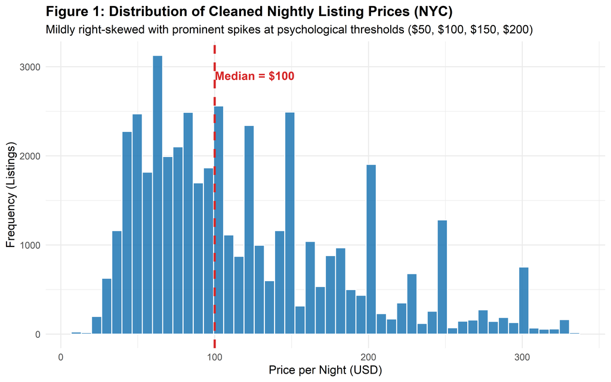

```r
ggplot(listings_model, aes(x = price)) +
  geom_histogram(bins = 50, fill = "#1f77b4", color = "white", alpha = 0.85) +
  geom_vline(aes(xintercept = median(price)), color = "#d62728", linetype = "dashed", linewidth = 1) +
  annotate("text", x = median(listings_model$price) + 26, y = 2900,
           label = paste0("Median = $", round(median(listings_model$price), 1)),
           color = "#d62728", fontface = "bold") +
  labs(
    title = "Figure 1: Distribution of Cleaned Nightly Listing Prices (NYC)",
    subtitle = "Mildly right-skewed with prominent spikes at psychological thresholds ($50, $100, $150, $200)",
    x = "Price per Night (USD)",
    y = "Frequency (Listings)"
  ) +
  theme_minimal(base_size = 11) +
  theme(plot.title = element_text(face = "bold"))
```

### 5.0.2 2. Price by Room Type

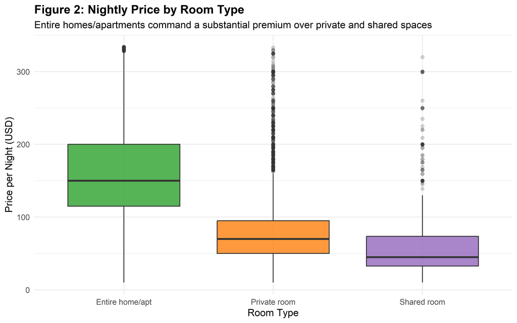

```r
ggplot(listings_model, aes(x = room_type, y = price, fill = room_type)) +
  geom_boxplot(alpha = 0.8, outlier.alpha = 0.2, show.legend = FALSE) +
  scale_fill_manual(values = c("Entire home/apt" = "#2ca02c", "Private room" = "#ff7f0e", "Shared room" = "#9467bd")) +
  labs(
    title = "Figure 2: Nightly Price by Room Type",
    subtitle = "Entire homes/apartments command a substantial premium over private and shared spaces",
    x = "Room Type",
    y = "Price per Night (USD)"
  ) +
  theme_minimal(base_size = 11) +
  theme(plot.title = element_text(face = "bold"))
```

### 5.0.3 3. Median Price by Borough (Neighbourhood Group)

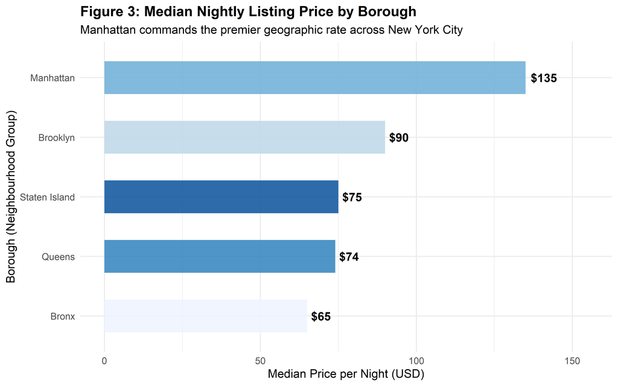

```r
listings_model %>%
  group_by(neighbourhood_group) %>%
  summarise(median_price = median(price), .groups = "drop") %>%
  ggplot(aes(x = reorder(neighbourhood_group, median_price), y = median_price, fill = neighbourhood_group)) +
  geom_col(alpha = 0.85, width = 0.55, show.legend = FALSE) +
  geom_text(aes(label = paste0("$", round(median_price, 1))), hjust = -0.2, fontface = "bold") +
  coord_flip(ylim = c(0, 155)) +
  scale_fill_brewer(palette = "Blues") +
  labs(
    title = "Figure 3: Median Nightly Listing Price by Borough",
    subtitle = "Manhattan commands the premier geographic rate across New York City",
    x = "Borough (Neighbourhood Group)",
    y = "Median Price per Night (USD)"
  ) +
  theme_minimal(base_size = 11) +
  theme(plot.title = element_text(face = "bold"))
```